# Práctico 1 - Estadística

## Consigna 1

> En estadística una población es un conjunto de sujetos, individuos, elementos o eventos con determinadas características. – Fuente: Wikipedia

> En estadística, una muestra es un subconjunto de casos o individuos de una población. – Fuente: Wikipedia

**Respuesta 1**: Es una muestra. Ya que la población es el conjunto de empresas de Río Cuarto censadas (censo=totalidad) en el año 2007

**Respuesta 2**: Es una muestra. Ya que el filtro de la selección se define como “principales”. Distinto hubiese sido si su hubiera definido, las empresas Químicas de Río Cuarto. En este último caso sabemos que son todas que tiene dicha actividad.

## Tabla de Datos

```r
load('datos.RData')
datos
```

| Empresa | Ventas | Insumos | Materia Prima | Gastos | Activo | Pasivo | Actividad | Empleo |
| --- | --- | --- | --- | --- | --- | --- | --- | --- |
| 27 | 77493920 | 30314091.0 | 38045414.0 | 8993486.0 | 61029293.0 | 14759644.00 | Alimentos | 162 |
| 44 | 22191193 | 18905188.0 | 11872288.3 | 1909105.0 | 5535895.0 | 2340818.00 | Maquinaria | 20 |
| 25 | 11200000 | 6060000.0 | 5558560.0 | 5486000.0 | 4900000.0 | 3175000.00 | Alimentos | 102 |
| 28 | 9442215 | 1133065.8 | 5604863.0 | 749749.0 | 3415088.7 | 10016110.00 | Maquinaria | 87 |
| 19 | 5848392 | 3864210.0 | 2902556.9 | 1672247.0 | 1959555.0 | 650374.00 | Alimentos | 41 |
| 36 | 5483673 | 1954929.5 | 3226492.0 | 978928.7 | 3928636.8 | 2707697.61 | Alimentos | 62 |
| 39 | 4225118 | 950299.6 | 2102841.4 | 1450296.2 | 2092191.9 | 1319591.81 | Alimentos | 37 |
| 31 | 3564877 | 855329.0 | 1995769.0 | 977444.0 | 721398.0 | 334725.00 | Alimentos | 37 |
| 46 | 3433927 | 1844705.6 | 2627437.0 | 256403.0 | 884597.0 | 168231.00 | Químicos | 25 |
| 40 | 2990823 | 358898.8 | 1445971.0 | 1138044.0 | 85606.0 | 489029.00 | Maquinaria | 27 |

[output cut: 10 more lines]

## Consigna 2

```r
mVentas <- mean(datos$Ventas)
mActivo <- mean(datos$Activo)
mPasivo <- mean(datos$Pasivo)
mEmpleo <- mean(datos$Empleo)
```

Media de Ventas = 8191174.2615

Media de Activo = 5472813.2715

Media de Pasivo = 1912996.2115

Media de Empleo = 41.25

## Consigna 3

```r
a3 <- table(datos$Actividad)
a3p <- prop.table(a3)
pactAlimentos <- a3p[1] * 100
pactMadera <- a3p[2] * 100
pactMaquinaria <- a3p[3] * 100
pactMetal <- a3p[4] * 100
pactPNC <- a3p[5] * 100
nactPNC <- a3["PNC"]
```

Porcentaje de Empresas de Avtidad Alimentos: 45 %

Total de Empresasa de Actividad PNC: 3

Porcentaje de Empresas de Actidad PNC: 15 %

## Consigna 4

** Gráfico de Barras**

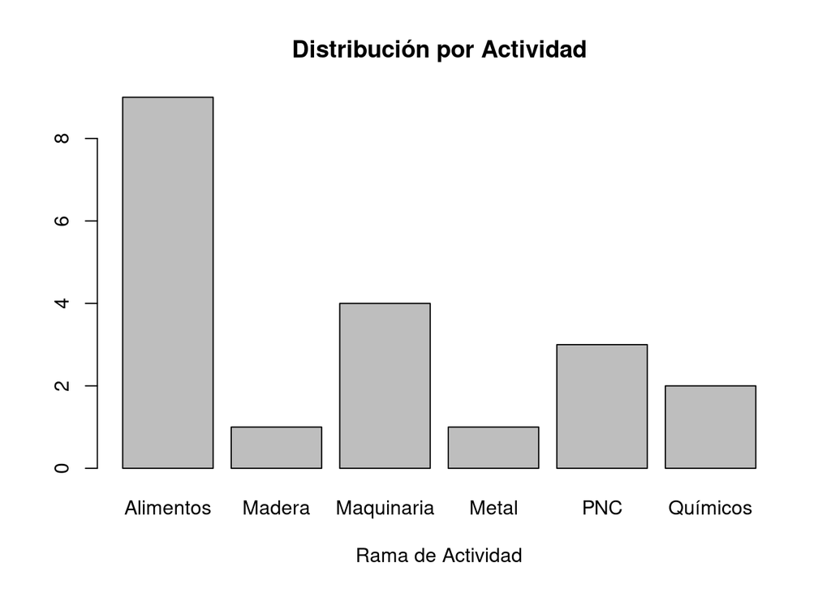

```r
counts <- table(datos$Actividad)
barplot(counts, main="Distribución por Actividad", xlab = "Rama de Actividad")
```

**Gráfico de Torta o de Sectores**

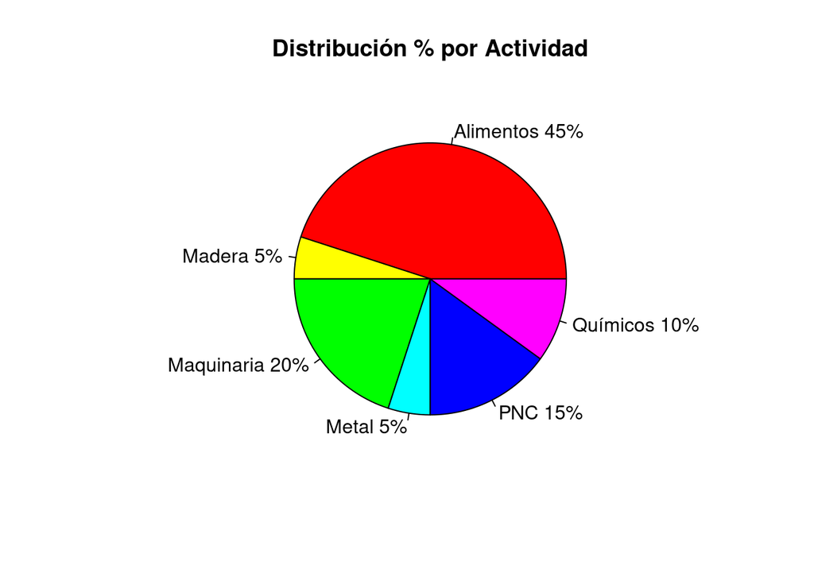

```r
mytable <- table(datos$Actividad)
lbls <- paste(names(mytable), " ", mytable/sum(mytable)*100, sep="") #Contruir porcentaje
lbls <- paste(lbls,"%",sep="") # ad % to labels  #Añadir Porcentaje
pie(mytable, labels = lbls,col=rainbow(length(lbls)), main="Distribución % por Actividad")
```

## Consigna 5

Frecuencia variable Actividad

```r
x = datos$Actividad
cbind(Frecuencia = table(x), Frecuencia_Relativa = table(x) / length(x), Frecuencia_Acumulada = cumsum(table(x)))
```

```
##            Frecuencia Frecuencia_Relativa Frecuencia_Acumulada
## Alimentos           9                0.45                    9
## Madera              1                0.05                   10
## Maquinaria          4                0.20                   14
## Metal               1                0.05                   15
## PNC                 3                0.15                   18
## Químicos            2                0.10                   20
```

Porcentaje de Frecuencia variable Actividad

```r
x <- table(datos$Actividad)
xx <- prop.table(x)
cbind(prop.table(x)) * 100
```

```
##            [,1]
## Alimentos    45
## Madera        5
## Maquinaria   20
## Metal         5
## PNC          15
## Químicos     10
```

Porcentajes Acumulados

```r
frequency::freq(datos$Actividad, type = "html")
```

```
## Building tables
```

```
## $`x:`
##                     x label Freq Percent Valid Percent Cumulative Percent
## 2    Valid  Alimentos          9    45.0          45.0               45.0
## 3              Madera          1     5.0           5.0               50.0
## 4          Maquinaria          4    20.0          20.0               70.0
## 5               Metal          1     5.0           5.0               75.0
## 6                 PNC          3    15.0          15.0               90.0
## 7            Químicos          2    10.0          10.0              100.0
## 71              Total         20   100.0         100.0
## 1  Missing    <blank>          0     0.0
## 8                <NA>          0     0.0
## 10              Total         20   100.0
```